# Machine Learning

Brian Papiernik, Casey Kmet, JD Bertrand, Kiki VanZanten, Quinn Murphy

2023-09-28

## Load Packages

```r
# install.packages("randomForest")
# install.packages("rpart")
# install.packages("caret")
library(randomForest) # Load randomForest package to run bagging
library(rpart) # Load rpart for decision trees
library(caret) # Used for analysing results
#install.packages("splitstackshape")
library(splitstackshape) # Used for stratified sampling
```

```r
#install.packages("xgboost")
#install.packages("caret")
#install.packages("ggplot2")
#library(devtools)
#install.packages("githubinstall")
library(devtools)
#install_github("AppliedDataSciencePartners/xgboostExplainer")
#install.packages("SHAPforxgboost")
#install.packages("GGally")
#install.packages("gh")

library(xgboost) # Load XGBoost
library(caret) # Load Caret
library(ggplot2) # Load ggplot2
library(pROC) # Load proc
library(SHAPforxgboost) # Load shap for XGBoost
library(caTools)
library(dplyr)
library(GGally)
library(ggplot2) # Load ggplot2
library(pROC) # Load proc
library(data.table)
library(gh)
library(commonmark)
library(xgboostExplainer)
library(dplyr)
```

##Preparations

The lines below are how we ended up merging our two datasets: wide receiver stats dataset and wide receiver contract dataset. Once we exported the data frame WRData as a csv, our group decided to remove these lines from a chunk and only load our .csv into r through read.csv. This was done for knitting purposes.

WRData <- merge(widereciver_xls, widereciver_xls2, by = “player_name”, all = TRUE)

WRData <- WRData[!is.na(WRData$team),] WRData <- WRData[!is.na(WRData$contract_length),]

WRData

```r
WRData <- read.csv("widereceiver.csv")

WRData
```

```
##                  player_name team player_age Position games_played
## 1                 A.J. Brown  PHI         25       WR           17
## 2               Adam Thielen  MIN         32       WR           17
## 3                Alec Pierce  IND         22       WR           16
## 4               Allen Lazard  GNB         27       WR           15
## 5             Allen Robinson  LAR         29       WR           10
## 6               Amari Cooper  CLE         28       WR           17
## 7          Amon-Ra St. Brown  DET         23       WR           16
## 8               Ashton Dulin  IND         25       WR           12
## 9              Ben Skowronek  LAR         25       WR           14
## 10             Brandin Cooks  HOU         29       WR           13
## 11             Brandon Aiyuk  SFO         24       WR           17
## 12           Brandon Johnson  DEN         24       WR            7
## 13            Brandon Powell  LAR         27       WR           17
## 14           Braxton Berrios  NYJ         27       WR           17
```

[output cut: 986 more lines]

The table above is the correct dataset. It has 142 total receivers and their values for 26 different variables.

```r
set.seed(1)

#Use 80% of dataset as training set and remaining 20% as testing set
sample <- sample.split(WRData$contract_AAV, SplitRatio = 0.8)
WR_train  <- subset(WRData, sample == TRUE)
WR_test   <- subset(WRData, sample == FALSE)
dim(WR_train)
```

```
## [1] 113  26
```

```r
dim(WR_test)
```

```
## [1] 29 26
```

In the code above, our group creates two new datasets: training set and testing set. The training set WR_train has 113 total wide receivers along with the values for 26 different variables. The testing set WR_test has 29 total wide receivers along with the values for 26 different variables.

```r
head(WRData) #Check first few rows
```

```
##      player_name team player_age Position games_played games_started
## 1     A.J. Brown  PHI         25       WR           17            16
## 2   Adam Thielen  MIN         32       WR           17            17
## 3    Alec Pierce  IND         22       WR           16            12
## 4   Allen Lazard  GNB         27       WR           15            15
## 5 Allen Robinson  LAR         29       WR           10            10
## 6   Amari Cooper  CLE         28       WR           17            17
##   player_targets player_rec player_catch_percentage player_yards player_ypr
## 1            145         88                   0.607         1496       17.0
## 2            107         70                   0.654          716       10.2
## 3             78         41                   0.526          593       14.5
## 4            100         60                   0.600          788       13.1
## 5             52         33                   0.635          339       10.3
## 6            132         78                   0.591         1160       14.9
##   player_td player_first_downs player_success longest_reception
```

[output cut: 27 more lines]

The code above checks the first 6 rows for the WRData

```r
tail(WRData) #Check last few rows of data
```

```
##         player_name team player_age Position games_played games_started
## 137   Tyler Lockett  SEA         30       WR           16            16
## 138 Tyquan Thornton  NWE         22       WR           13             9
## 139     Tyreek Hill  MIA         28       WR           17            17
## 140   Van Jefferson  LAR         26       WR           11             9
## 141     Zach Pascal  PHI         28       WR           17             2
## 142       Zay Jones  JAX         27       WR           16            15
##     player_targets player_rec player_catch_percentage player_yards player_ypr
## 137            117         84                   0.718         1033       12.3
## 138             45         22                   0.489          247       11.2
## 139            170        119                   0.700         1710       14.4
## 140             44         24                   0.545          369       15.4
## 141             19         15                   0.789          150       10.0
## 142            121         82                   0.678          823       10.0
##     player_td player_first_downs player_success longest_reception
```

[output cut: 27 more lines]

The code above checks the last 6 rows for the WRData

```r
summary(WRData) #Summarise Data
```

```
##  player_name            team             player_age      Position
##  Length:142         Length:142         Min.   :21.00   Length:142
##  Class :character   Class :character   1st Qu.:23.00   Class :character
##  Mode  :character   Mode  :character   Median :26.00   Mode  :character
##                                        Mean   :25.73
##                                        3rd Qu.:28.00
##                                        Max.   :33.00
##
##   games_played   games_started    player_targets     player_rec
##  Min.   : 1.00   Min.   : 0.000   Min.   :  1.00   Min.   :  0.00
##  1st Qu.:10.25   1st Qu.: 2.000   1st Qu.: 20.50   1st Qu.: 13.25
##  Median :15.00   Median : 8.000   Median : 60.00   Median : 37.00
##  Mean   :13.03   Mean   : 7.915   Mean   : 63.44   Mean   : 40.85
##  3rd Qu.:17.00   3rd Qu.:13.000   3rd Qu.: 96.00   3rd Qu.: 63.75
##  Max.   :17.00   Max.   :17.000   Max.   :184.00   Max.   :128.00
##
##  player_catch_percentage  player_yards      player_ypr      player_td
##  Min.   :0.0000          Min.   :   0.0   Min.   : 3.00   Min.   : 0.000
##  1st Qu.:0.5780          1st Qu.: 154.5   1st Qu.:10.00   1st Qu.: 1.000
##  Median :0.6430          Median : 439.0   Median :11.90   Median : 2.000
##  Mean   :0.6382          Mean   : 510.8   Mean   :12.54   Mean   : 2.944
##  3rd Qu.:0.7007          3rd Qu.: 783.2   3rd Qu.:14.20   3rd Qu.: 4.000
##  Max.   :1.0000          Max.   :1809.0   Max.   :41.00   Max.   :14.000
##                                           NA's   :1
##  player_first_downs player_success   longest_reception player_yards_per_target
##  Min.   : 0.00      Min.   :  0.00   Min.   : 0.00     Min.   : 0.000
##  1st Qu.: 7.00      1st Qu.: 44.75   1st Qu.:29.25     1st Qu.: 6.500
##  Median :22.50      Median : 51.35   Median :42.00     Median : 7.600
##  Mean   :24.59      Mean   : 49.72   Mean   :41.33     Mean   : 7.658
##  3rd Qu.:38.00      3rd Qu.: 56.48   3rd Qu.:54.00     3rd Qu.: 8.800
##  Max.   :80.00      Max.   :100.00   Max.   :98.00     Max.   :16.000
##
##  receptions_per_game yards_per_game   player_target_per_game player_td_per_game
##  Min.   :0.000       Min.   :  0.00   Min.   : 0.1538        Min.   :0.0000
##  1st Qu.:1.300       1st Qu.: 14.47   1st Qu.: 2.0000        1st Qu.:0.0625
##  Median :2.800       Median : 33.70   Median : 4.5312        Median :0.1818
##  Mean   :2.942       Mean   : 36.34   Mean   : 4.5641        Mean   :0.2202
##  3rd Qu.:4.375       3rd Qu.: 52.12   3rd Qu.: 6.8460        3rd Qu.:0.3281
##  Max.   :8.300       Max.   :106.40   Max.   :11.1667        Max.   :1.0000
##
##  player_first_downs_per_game contract_length contract_value
##  Min.   :0.0000              Min.   :1.000   Min.   :   800000
##  1st Qu.:0.7112              1st Qu.:1.000   1st Qu.:  2579375
##  Median :1.6863              Median :3.000   Median :  5115312
##  Mean   :1.7456              Mean   :2.789   Mean   : 18251154
##  3rd Qu.:2.6415              3rd Qu.:4.000   3rd Qu.: 20450852
##  Max.   :4.8333              Max.   :5.000   Max.   :140000000
##
##   contract_AAV      contract_bonus     contract_gteed
##  Min.   :  787500   Length:142         Length:142
##  1st Qu.: 1088546   Class :character   Class :character
##  Median : 2203402   Mode  :character   Mode  :character
##  Mean   : 5683155
##  3rd Qu.: 6578624
##  Max.   :30000000
##
```

The code above shows the summary statistics for our 26 variables

```r
dim(WRData)
```

```
## [1] 142  26
```

```r
summary(WRData)
```

```
##  player_name            team             player_age      Position
##  Length:142         Length:142         Min.   :21.00   Length:142
##  Class :character   Class :character   1st Qu.:23.00   Class :character
##  Mode  :character   Mode  :character   Median :26.00   Mode  :character
##                                        Mean   :25.73
##                                        3rd Qu.:28.00
##                                        Max.   :33.00
##
##   games_played   games_started    player_targets     player_rec
##  Min.   : 1.00   Min.   : 0.000   Min.   :  1.00   Min.   :  0.00
##  1st Qu.:10.25   1st Qu.: 2.000   1st Qu.: 20.50   1st Qu.: 13.25
##  Median :15.00   Median : 8.000   Median : 60.00   Median : 37.00
##  Mean   :13.03   Mean   : 7.915   Mean   : 63.44   Mean   : 40.85
##  3rd Qu.:17.00   3rd Qu.:13.000   3rd Qu.: 96.00   3rd Qu.: 63.75
##  Max.   :17.00   Max.   :17.000   Max.   :184.00   Max.   :128.00
##
##  player_catch_percentage  player_yards      player_ypr      player_td
##  Min.   :0.0000          Min.   :   0.0   Min.   : 3.00   Min.   : 0.000
##  1st Qu.:0.5780          1st Qu.: 154.5   1st Qu.:10.00   1st Qu.: 1.000
##  Median :0.6430          Median : 439.0   Median :11.90   Median : 2.000
##  Mean   :0.6382          Mean   : 510.8   Mean   :12.54   Mean   : 2.944
##  3rd Qu.:0.7007          3rd Qu.: 783.2   3rd Qu.:14.20   3rd Qu.: 4.000
##  Max.   :1.0000          Max.   :1809.0   Max.   :41.00   Max.   :14.000
##                                           NA's   :1
##  player_first_downs player_success   longest_reception player_yards_per_target
##  Min.   : 0.00      Min.   :  0.00   Min.   : 0.00     Min.   : 0.000
##  1st Qu.: 7.00      1st Qu.: 44.75   1st Qu.:29.25     1st Qu.: 6.500
##  Median :22.50      Median : 51.35   Median :42.00     Median : 7.600
##  Mean   :24.59      Mean   : 49.72   Mean   :41.33     Mean   : 7.658
##  3rd Qu.:38.00      3rd Qu.: 56.48   3rd Qu.:54.00     3rd Qu.: 8.800
##  Max.   :80.00      Max.   :100.00   Max.   :98.00     Max.   :16.000
##
##  receptions_per_game yards_per_game   player_target_per_game player_td_per_game
##  Min.   :0.000       Min.   :  0.00   Min.   : 0.1538        Min.   :0.0000
##  1st Qu.:1.300       1st Qu.: 14.47   1st Qu.: 2.0000        1st Qu.:0.0625
##  Median :2.800       Median : 33.70   Median : 4.5312        Median :0.1818
##  Mean   :2.942       Mean   : 36.34   Mean   : 4.5641        Mean   :0.2202
##  3rd Qu.:4.375       3rd Qu.: 52.12   3rd Qu.: 6.8460        3rd Qu.:0.3281
##  Max.   :8.300       Max.   :106.40   Max.   :11.1667        Max.   :1.0000
##
##  player_first_downs_per_game contract_length contract_value
##  Min.   :0.0000              Min.   :1.000   Min.   :   800000
##  1st Qu.:0.7112              1st Qu.:1.000   1st Qu.:  2579375
##  Median :1.6863              Median :3.000   Median :  5115312
##  Mean   :1.7456              Mean   :2.789   Mean   : 18251154
##  3rd Qu.:2.6415              3rd Qu.:4.000   3rd Qu.: 20450852
##  Max.   :4.8333              Max.   :5.000   Max.   :140000000
##
##   contract_AAV      contract_bonus     contract_gteed
##  Min.   :  787500   Length:142         Length:142
##  1st Qu.: 1088546   Class :character   Class :character
##  Median : 2203402   Mode  :character   Mode  :character
##  Mean   : 5683155
##  3rd Qu.: 6578624
##  Max.   :30000000
##
```

For our response variable we are going to use AAV (Average Annual Value)

```r
summary(WRData$contract_AAV)
```

```
##     Min.  1st Qu.   Median     Mean  3rd Qu.     Max.
##   787500  1088546  2203402  5683155  6578624 30000000
```

We learn from this that the lowest a player makes is $787,500 and the most a player makes is $30,000,000. It is interesting to see that the mean is greater than the median which means that the dataset is positive right skewed which makes sense because a lot of receivers are either on rookie contracts or team-friendly contracts. Only top tier receivers are making top tier contract AAV. The mean for all receivers is $5,683,155.

##Data Exploration Looking at contract lengths of WR’s

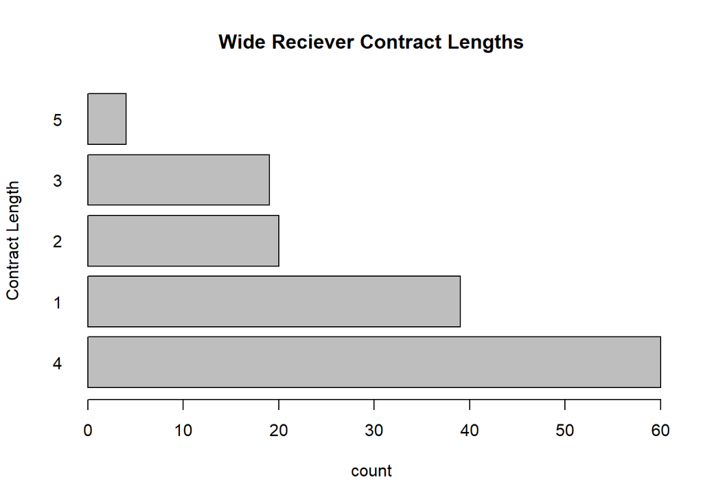

```r
barplot(sort(table(WRData$contract_length),
        decreasing=TRUE),
        horiz=TRUE,
        las=1,
        main="Wide Reciever Contract Lengths", ylab="Contract Length",xlab="count")
```

Majority of NFL long term deals are 4 years and rarely are 5 years. Most players have shorter term deals (1-2 years) if they are not signed to a 4 year deal.

Player Age Breakdowns

```r
table(WRData$player_age)
```

```
##
## 21 22 23 24 25 26 27 28 29 30 32 33
##  3 14 21 14 18 19 14 12 15  7  4  1
```

##Correlation Analysis

```r
WR_DataCor <-  WRData %>%
  select(contract_AAV,games_played, player_ypr, player_success, player_yards_per_target, receptions_per_game,yards_per_game, player_target_per_game, player_td_per_game, player_first_downs_per_game)
```

```r
cor(WR_DataCor)[,"contract_AAV"]
```

```
##                contract_AAV                games_played
##                   1.0000000                   0.2173715
##                  player_ypr              player_success
##                          NA                   0.1695952
##     player_yards_per_target         receptions_per_game
##                   0.1409380                   0.6271376
##              yards_per_game      player_target_per_game
##                   0.6440124                   0.6406779
##          player_td_per_game player_first_downs_per_game
##                   0.4840635                   0.6422742
```

The code above how the variable: contract_AAV is correlated with the rest of the variables in the WR_DataCor dataset. It is interesting to see 4 variables correlated near 0.64 with contract_AAV.

# Visuals

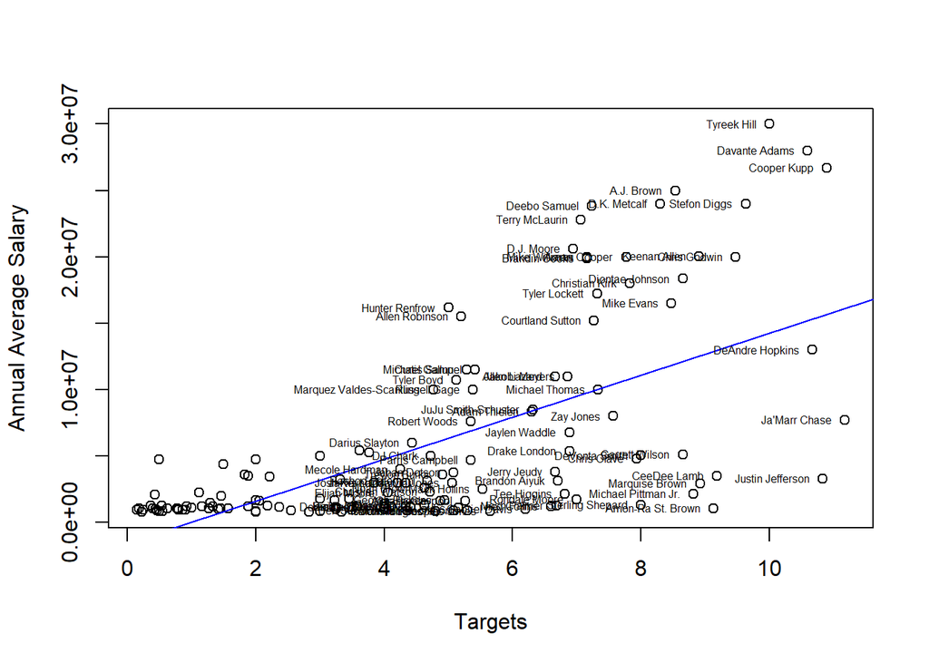

```r
##Comparing Salary AAV to Field Preformance

plot(WRData$player_target_per_game, WRData$contract_AAV, xlab='Targets', ylab='Annual Average Salary')
abline(lm(WRData$contract_AAV ~ WRData$player_target_per_game), col="blue")
text(WRData$player_target_per_game[which(WRData$player_target_per_game > 4)], WRData$contract_AAV[which(WRData$player_target_per_game > 4)], labels=WRData$player_name[which(WRData$player_target_per_game > 4)],cex = .5, pos = 2)
```

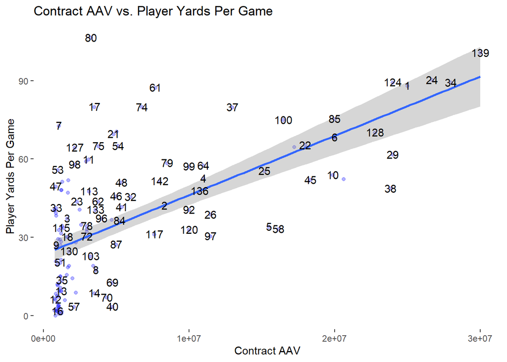

```r
yardsvsAAv <- ggplot(WRData, # Set dataset
              aes(y = yards_per_game, # Set y-axis as insurance charges
                  x = contract_AAV)) + # Set x-axis as bmi.
  geom_point(color = "blue", alpha = 0.3) + # Use geom_point to get scatter plot
  geom_smooth(method = "lm") + # Add smoothing line
  theme_bw() + # Set theme for plot
  theme(panel.grid.major = element_blank(), # Turn of the background grid
        panel.grid.minor = element_blank(),
        panel.border = element_blank(),
        panel.background = element_blank()) +
  labs(y = "Player Yards Per Game", # Set plot labels
       x = "Contract AAV",
       title = "Contract AAV vs. Player Yards Per Game") +
  geom_text( data = WRData[], inherit.aes = FALSE,
              aes(y = yards_per_game, # Set y-axis as insurance charges
                  x = contract_AAV),
    label=rownames(WRData),
    nudge_x = 0.25, nudge_y = 0.25,
    check_overlap = T)


yardsvsAAv # Generate plot
```

This visual above shows the relationship between the x-axis Contract AAV and the y-axis Player Yards Per Game. Each point on the graph is index by the row for each receiver in the WRData set. It is interesting to note that the players above the trend line overperforming their Player Yards Per Game based on their Contract AAV. The players below the trend line are underperforming their Player Yards Per Game based on their Contract AAV. Point 80 is Justin Jefferson who is still on his rookie contract, so he is massively out performing his contract.

# Regression Analysis

```r
WR_regression <-
  WRData %>% select(contract_AAV,games_played, player_ypr, player_success, player_yards_per_target, receptions_per_game,yards_per_game, player_target_per_game, player_td_per_game, player_first_downs_per_game )
WRFIT1 <- lm(contract_AAV~., data= WR_regression)
summary(WRFIT1)
```

```
##
## Call:
## lm(formula = contract_AAV ~ ., data = WR_regression)
##
## Residuals:
##       Min        1Q    Median        3Q       Max
## -14858571  -3148931   -299724   2063875  15901580
##
## Coefficients:
##                             Estimate Std. Error t value Pr(>|t|)
## (Intercept)                  1164039    2892413   0.402    0.688
## games_played                    6116     123425   0.050    0.961
## player_ypr                    104960     164635   0.638    0.525
## player_success                 24947      51537   0.484    0.629
## player_yards_per_target      -687836     500433  -1.374    0.172
## receptions_per_game          -784433    1601003  -0.490    0.625
## yards_per_game                170623     112519   1.516    0.132
## player_target_per_game        212045    1150513   0.184    0.854
## player_td_per_game            643583    3624107   0.178    0.859
## player_first_downs_per_game  1238070    1999562   0.619    0.537
##
## Residual standard error: 5553000 on 131 degrees of freedom
##   (1 observation deleted due to missingness)
## Multiple R-squared:  0.4359, Adjusted R-squared:  0.3972
## F-statistic: 11.25 on 9 and 131 DF,  p-value: 6.643e-13
```

# Preparing Data for XGBoost

```r
dtrain <- xgb.DMatrix(data = as.matrix(WR_train[, c(3, 5:21)]), label = as.numeric(WR_train$contract_AAV))
# Create test matrix
dtest <- xgb.DMatrix(data = as.matrix(WR_test[, c(3, 5:21)]), label = as.numeric(WR_test$contract_AAV))
```

XGBoost uses its own data type called DMatrix that is an efficient method for storing sparse matrices (Many zeros).

# Training our XGBoost Model

```r
set.seed(111111)
bst_1 <- xgboost(data = dtrain, # Set training data

               nrounds = 100, # Set number of rounds

               verbose = 1, # 1 - Prints out fit
                print_every_n = 20) # Prints out result every 20th iteration
set.seed(111111)
bst <- xgb.cv(data = dtrain, # Set training data

              nfold = 5, # Use 5 fold cross-validation

               eta = 0.1, # Set learning rate

               nrounds = 1000, # Set number of rounds
               early_stopping_rounds = 50, # Set number of rounds to stop at if there is no improvement

               verbose = 1, # 1 - Prints out fit
               nthread = 1, # Set number of parallel threads
               print_every_n = 20) # Prints out result every 20th iteration
```

```
## Multiple eval metrics are present. Will use test_rmse for early stopping.
## Will train until test_rmse hasn't improved in 50 rounds.
##
## Stopping. Best iteration:
```

From this we see 24 was the optimal number of iterations for our model. We use this number solely to ensure that we are doing a sufficient amount of rounds for our next tuning stages. We will set the number of iterations to 100 and include an early stop parameter of 20 for our next round of tuning.

```r
max_depth_vals <- c(3, 5, 7, 10, 15) # Create vector of max depth values
min_child_weight <- c(1,3,5,7, 10, 15) # Create vector of min child values

# Expand grid of parameter values
cv_params <- expand.grid(max_depth_vals, min_child_weight)
names(cv_params) <- c("max_depth", "min_child_weight")
# Create results vector
rmse_vec  <- rep(NA, nrow(cv_params))
# Loop through results
for(i in 1:nrow(cv_params)){
  set.seed(111111)
  bst_tune <- xgb.cv(data = dtrain, # Set training data

                     nfold = 5, # Use 5 fold cross-validation

                     eta = 0.1, # Set learning rate
                     max.depth = cv_params$max_depth[i], # Set max depth
                     min_child_weight = cv_params$min_child_weight[i], # Set minimum number of samples in node to split


                     nrounds = 100, # Set number of rounds
                     early_stopping_rounds = 20, # Set number of rounds to stop at if there is no improvement

                     verbose = 1, # 1 - Prints out fit
                     nthread = 1, # Set number of parallel threads
                     print_every_n = 20 # Prints out result every 20th iteration

  ) # Set evaluation metric to use

  rmse_vec[i] <- bst_tune$evaluation_log$test_rmse_mean[bst_tune$best_ntreelimit]


}
```

[output not shown]

[output cut: 94 more lines]

```
##
## Multiple eval metrics are present. Will use test_rmse for early stopping.
## Will train until test_rmse hasn't improved in 20 rounds.
##
## Stopping. Best iteration:
##
## Multiple eval metrics are present. Will use test_rmse for early stopping.
## Will train until test_rmse hasn't improved in 20 rounds.
##
## Stopping. Best iteration:
##
## Multiple eval metrics are present. Will use test_rmse for early stopping.
## Will train until test_rmse hasn't improved in 20 rounds.
##
## Stopping. Best iteration:
```

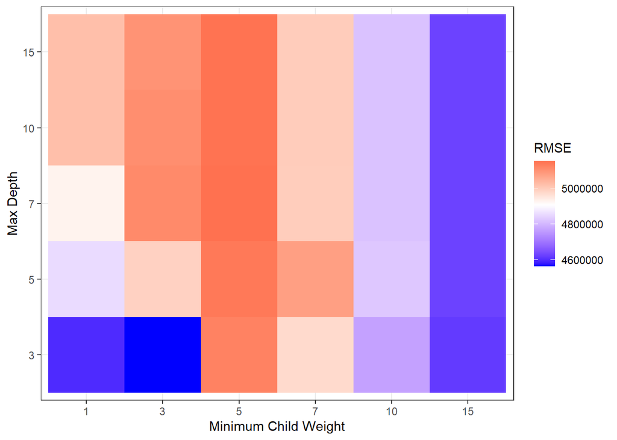

```r
# Join results in dataset
res_db <- cbind.data.frame(cv_params, rmse_vec)
names(res_db)[3] <- c("rmse")
res_db$max_depth <- as.factor(res_db$max_depth) # Convert tree number to factor for plotting
res_db$min_child_weight <- as.factor(res_db$min_child_weight) # Convert node size to factor for plotting
# Print AUC heatmap
g_2 <- ggplot(res_db, aes(y = max_depth, x = min_child_weight, fill = rmse)) + # set aesthetics
  geom_tile() + # Use geom_tile for heatmap
  theme_bw() + # Set theme
  scale_fill_gradient2(low = "blue", # Choose low color
                       mid = "white", # Choose mid color
                       high = "red", # Choose high color
                       midpoint =mean(res_db$rmse), # Choose mid point
                       space = "Lab",
                       na.value ="grey", # Choose NA value
                       guide = "colourbar", # Set color bar
                       aesthetics = "fill") + # Select aesthetics to apply
  labs(x = "Minimum Child Weight", y = "Max Depth", fill = "RMSE") # Set labels
g_2 # Generate plot
```

```r
res_db
```

```
##    max_depth min_child_weight    rmse
## 1          3                1 4597944
## 2          5                1 4855920
## 3          7                1 4930958
## 4         10                1 5023153
## 5         15                1 5023153
## 6          3                3 4565062
## 7          5                3 4991294
## 8          7                3 5114280
## 9         10                3 5107140
## 10        15                3 5099442
## 11         3                5 5126549
## 12         5                5 5141762
## 13         7                5 5153302
## 14        10                5 5150023
```

[output cut: 16 more lines]

```r
res_db[which.min(res_db$rmse),] # View best set of results
```

```
##   max_depth min_child_weight    rmse
## 6         3                3 4565062
```

```r
gamma_vals <- c(0, 0.05, 0.1, 0.15, 0.2) # Create vector of gamma values

# Be Careful - This can take a very long time to run
set.seed(111111)
rmse_vec  <- rep(NA, length(gamma_vals))
for(i in 1:length(gamma_vals)){
  bst_tune <- xgb.cv(data = dtrain, # Set training data

                     nfold = 5, # Use 5 fold cross-validation

                     eta = 0.1, # Set learning rate
                     max.depth = 3, # Set max depth
                     min_child_weight = 3, # Set minimum number of samples in node to split
                     gamma = gamma_vals[i], # Set minimum loss reduction for split



                     nrounds = 100, # Set number of rounds
                     early_stopping_rounds = 20, # Set number of rounds to stop at if there is no improvement

                     verbose = 1, # 1 - Prints out fit
                     nthread = 1, # Set number of parallel threads
                     print_every_n = 20 # Prints out result every 20th iteration
  ) # Set evaluation metric to use


  rmse_vec[i] <- bst_tune$evaluation_log$test_rmse_mean[bst_tune$best_ntreelimit]


}
```

```
## Multiple eval metrics are present. Will use test_rmse for early stopping.
## Will train until test_rmse hasn't improved in 20 rounds.
##
## Stopping. Best iteration:
##
## Multiple eval metrics are present. Will use test_rmse for early stopping.
## Will train until test_rmse hasn't improved in 20 rounds.
##
## Stopping. Best iteration:
##
## Multiple eval metrics are present. Will use test_rmse for early stopping.
## Will train until test_rmse hasn't improved in 20 rounds.
##
## Stopping. Best iteration:
##
## Multiple eval metrics are present. Will use test_rmse for early stopping.
## Will train until test_rmse hasn't improved in 20 rounds.
##
## Stopping. Best iteration:
##
## Multiple eval metrics are present. Will use test_rmse for early stopping.
## Will train until test_rmse hasn't improved in 20 rounds.
##
## Stopping. Best iteration:
```

```r
cbind.data.frame(gamma_vals, rmse_vec)
```

```
##   gamma_vals rmse_vec
## 1       0.00  4565062
## 2       0.05  4663984
## 3       0.10  4622595
## 4       0.15  4378086
## 5       0.20  5031312
```

Here we see that a gamma value of 0.15 gives us the lowest RMSE.

```r
###### 3 - Subsample and Column sample Tuning ######

# Be Careful - This can take a very long time to run
subsample <- c(0.6, 0.7, 0.8, 0.9, 1) # Create vector of subsample values
colsample_by_tree <- c(0.6, 0.7, 0.8, 0.9, 1) # Create vector of col sample values

# Expand grid of tuning parameters
cv_params <- expand.grid(subsample, colsample_by_tree)
names(cv_params) <- c("subsample", "colsample_by_tree")
# Create vectors to store results
rmse_vec <- rep(NA, nrow(cv_params))
# Loop through parameter values
for(i in 1:nrow(cv_params)){
  set.seed(111111)
  bst_tune <- xgb.cv(data = dtrain, # Set training data

                     nfold = 5, # Use 5 fold cross-validation

                     eta = 0.1, # Set learning rate
                     max.depth = 3, # Set max depth
                     min_child_weight = 3, # Set minimum number of samples in node to split
                     gamma = .15, # Set minimum loss reduction for split
                     subsample = cv_params$subsample[i], # Set proportion of training data to use in tree
                     colsample_bytree = cv_params$colsample_by_tree[i], # Set number of variables to use in each tree

                     nrounds = 150, # Set number of rounds
                     early_stopping_rounds = 20, # Set number of rounds to stop at if there is no improvement

                     verbose = 1, # 1 - Prints out fit
                     nthread = 1, # Set number of parallel threads
                     print_every_n = 20 # Prints out result every 20th iteration
  ) # Set evaluation metric to use


  rmse_vec[i] <- bst_tune$evaluation_log$test_rmse_mean[bst_tune$best_ntreelimit]


}
```

[output not shown]

[output cut: 69 more lines]

```
##
## Multiple eval metrics are present. Will use test_rmse for early stopping.
## Will train until test_rmse hasn't improved in 20 rounds.
##
## Stopping. Best iteration:
##
## Multiple eval metrics are present. Will use test_rmse for early stopping.
## Will train until test_rmse hasn't improved in 20 rounds.
##
## Stopping. Best iteration:
##
## Multiple eval metrics are present. Will use test_rmse for early stopping.
## Will train until test_rmse hasn't improved in 20 rounds.
##
## Stopping. Best iteration:
```

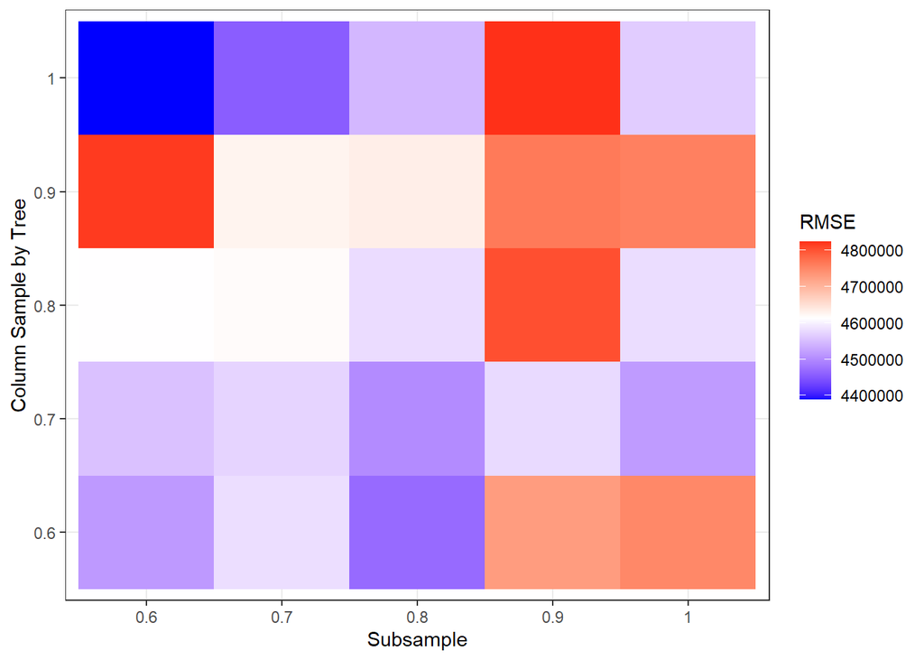

```r
# visualise tuning sample params

res_db <- cbind.data.frame(cv_params, rmse_vec)
names(res_db)[3] <- c("rmse")
res_db$subsample <- as.factor(res_db$subsample) # Convert tree number to factor for plotting
res_db$colsample_by_tree <- as.factor(res_db$colsample_by_tree) # Convert node size to factor for plotting
g_4 <- ggplot(res_db, aes(y = colsample_by_tree, x = subsample, fill = rmse)) + # set aesthetics
  geom_tile() + # Use geom_tile for heatmap
  theme_bw() + # Set theme
  scale_fill_gradient2(low = "blue", # Choose low color
                       mid = "white", # Choose mid color
                       high = "red", # Choose high color
                       midpoint =mean(res_db$rmse), # Choose mid point
                       space = "Lab",
                       na.value ="grey", # Choose NA value
                       guide = "colourbar", # Set color bar
                       aesthetics = "fill") + # Select aesthetics to apply
  labs(x = "Subsample", y = "Column Sample by Tree", fill = "RMSE") # Set labels
g_4 # Generate plot
```

```r
res_db
```

```
##    subsample colsample_by_tree    rmse
## 1        0.6               0.6 4515830
## 2        0.7               0.6 4583315
## 3        0.8               0.6 4469594
## 4        0.9               0.6 4728441
## 5          1               0.6 4750789
## 6        0.6               0.7 4555010
## 7        0.7               0.7 4572787
## 8        0.8               0.7 4501927
## 9        0.9               0.7 4578770
## 10         1               0.7 4517650
## 11       0.6               0.8 4613640
## 12       0.7               0.8 4618933
## 13       0.8               0.8 4581048
## 14       0.9               0.8 4804183
## 15         1               0.8 4581511
## 16       0.6               0.9 4818930
## 17       0.7               0.9 4627867
## 18       0.8               0.9 4634047
## 19       0.9               0.9 4764581
## 20         1               0.9 4758457
## 21       0.6                 1 4389643
## 22       0.7                 1 4456544
## 23       0.8                 1 4545243
## 24       0.9                 1 4824561
## 25         1                 1 4565062
```

From this it looks like the optimal values of the parameters to use are a subsample parameter of 0.6 and a colsample_by_tree of 1 because it has the lowest RMSE.

```r
###### 4 - eta tuning ######

# Use xgb.cv to run cross-validation inside xgboost
set.seed(111111)
bst_mod_1 <- xgb.cv(data = dtrain, # Set training data

                    nfold = 5, # Use 5 fold cross-validation

                    eta = 0.3, # Set learning rate
                    max.depth = 3, # Set max depth
                    min_child_weight = 3, # Set minimum number of samples in node to split
                    gamma = .15, # Set minimum loss reduction for split
                    subsample = 0.6, # Set proportion of training data to use in tree
                    colsample_bytree =  1, # Set number of variables to use in each tree

                    nrounds = 1000, # Set number of rounds
                    early_stopping_rounds = 20, # Set number of rounds to stop at if there is no improvement

                    verbose = 1, # 1 - Prints out fit
                    nthread = 1, # Set number of parallel threads
                    print_every_n = 20 # Prints out result every 20th iteration
) # Set evaluation metric to use
```

```
## Multiple eval metrics are present. Will use test_rmse for early stopping.
## Will train until test_rmse hasn't improved in 20 rounds.
##
## Stopping. Best iteration:
```

```r
set.seed(111111)
bst_mod_2 <- xgb.cv(data = dtrain, # Set training data

                    nfold = 5, # Use 5 fold cross-validation

                    eta = 0.1, # Set learning rate
                    max.depth =  3, # Set max depth
                    min_child_weight = 3, # Set minimum number of samples in node to split
                    gamma = .15, # Set minimum loss reduction for split
                    subsample = 0.6 , # Set proportion of training data to use in tree
                    colsample_bytree = 1, # Set number of variables to use in each tree

                    nrounds = 1000, # Set number of rounds
                    early_stopping_rounds = 20, # Set number of rounds to stop at if there is no improvement

                    verbose = 1, # 1 - Prints out fit
                    nthread = 1, # Set number of parallel threads
                    print_every_n = 20 # Prints out result every 20th iteration
) # Set evaluation metric to use
```

```
## Multiple eval metrics are present. Will use test_rmse for early stopping.
## Will train until test_rmse hasn't improved in 20 rounds.
##
## Stopping. Best iteration:
```

```r
set.seed(111111)
bst_mod_3 <- xgb.cv(data = dtrain, # Set training data

                    nfold = 5, # Use 5 fold cross-validation

                    eta = 0.05, # Set learning rate
                    max.depth = 3, # Set max depth
                    min_child_weight = 3 , # Set minimum number of samples in node to split
                    gamma = .15, # Set minimum loss reduction for split
                    subsample = 0.6 , # Set proportion of training data to use in tree
                    colsample_bytree =  1, # Set number of variables to use in each tree

                    nrounds = 1000, # Set number of rounds
                    early_stopping_rounds = 20, # Set number of rounds to stop at if there is no improvement

                    verbose = 1, # 1 - Prints out fit
                    nthread = 1, # Set number of parallel threads
                    print_every_n = 20 # Prints out result every 20th iteration
) # Set evaluation metric to use
```

```
## Multiple eval metrics are present. Will use test_rmse for early stopping.
## Will train until test_rmse hasn't improved in 20 rounds.
##
## Stopping. Best iteration:
```

```r
set.seed(111111)
bst_mod_4 <- xgb.cv(data = dtrain, # Set training data

                    nfold = 5, # Use 5 fold cross-validation

                    eta = 0.01, # Set learning rate
                    max.depth = 3, # Set max depth
                    min_child_weight = 3, # Set minimum number of samples in node to split
                    gamma = 0.15, # Set minimum loss reduction for split
                    subsample = 0.6 , # Set proportion of training data to use in tree
                    colsample_bytree = 1, # Set number of variables to use in each tree

                    nrounds = 1000, # Set number of rounds
                    early_stopping_rounds = 20, # Set number of rounds to stop at if there is no improvement

                    verbose = 1, # 1 - Prints out fit
                    nthread = 1, # Set number of parallel threads
                    print_every_n = 20 # Prints out result every 20th iteration
) # Set evaluation metric to use
```

```
## Multiple eval metrics are present. Will use test_rmse for early stopping.
## Will train until test_rmse hasn't improved in 20 rounds.
##
## Stopping. Best iteration:
```

```r
set.seed(111111)
bst_mod_5 <- xgb.cv(data = dtrain, # Set training data

                    nfold = 5, # Use 5 fold cross-validation

                    eta = 0.005, # Set learning rate
                    max.depth = 3, # Set max depth
                    min_child_weight = 3, # Set minimum number of samples in node to split
                    gamma = .15, # Set minimum loss reduction for split
                    subsample = 0.6 , # Set proportion of training data to use in tree
                    colsample_bytree = 1, # Set number of variables to use in each tree

                    nrounds = 1000, # Set number of rounds
                    early_stopping_rounds = 20, # Set number of rounds to stop at if there is no improvement

                    verbose = 1, # 1 - Prints out fit
                    nthread = 1, # Set number of parallel threads
                    print_every_n = 20 # Prints out result every 20th iteration

) # Set evaluation metric to use
```

```
## Multiple eval metrics are present. Will use test_rmse for early stopping.
## Will train until test_rmse hasn't improved in 20 rounds.
##
## Stopping. Best iteration:
```

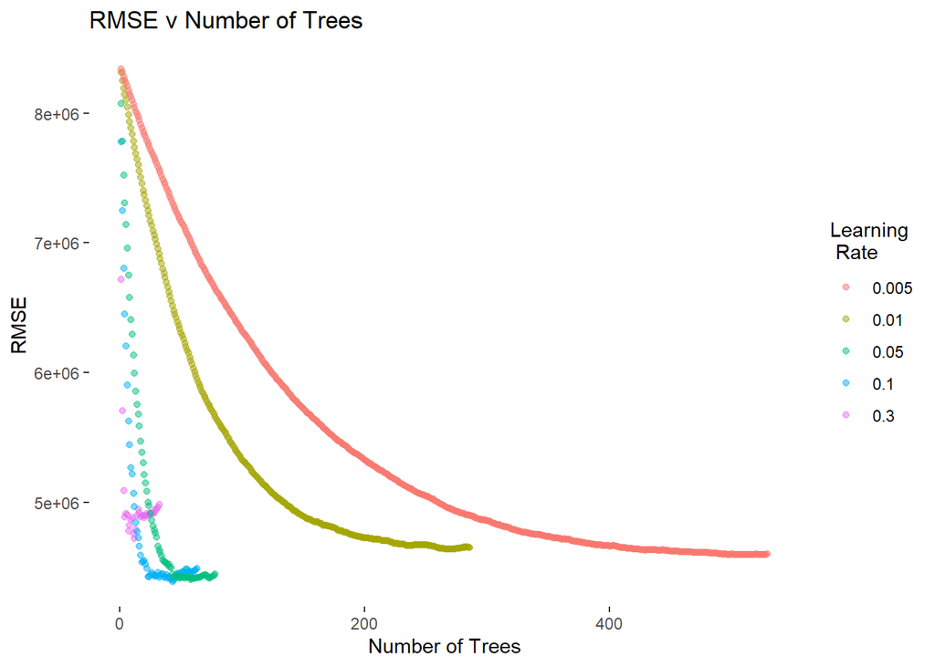

```r
# Extract results for model with eta = 0.3
pd1 <- cbind.data.frame(bst_mod_1$evaluation_log[,c("iter", "test_rmse_mean")], rep(0.3, nrow(bst_mod_1$evaluation_log)))
names(pd1)[3] <- "eta"
# Extract results for model with eta = 0.1
pd2 <- cbind.data.frame(bst_mod_2$evaluation_log[,c("iter", "test_rmse_mean")], rep(0.1, nrow(bst_mod_2$evaluation_log)))
names(pd2)[3] <- "eta"
# Extract results for model with eta = 0.05
pd3 <- cbind.data.frame(bst_mod_3$evaluation_log[,c("iter", "test_rmse_mean")], rep(0.05, nrow(bst_mod_3$evaluation_log)))
names(pd3)[3] <- "eta"
# Extract results for model with eta = 0.01
pd4 <- cbind.data.frame(bst_mod_4$evaluation_log[,c("iter", "test_rmse_mean")], rep(0.01, nrow(bst_mod_4$evaluation_log)))
names(pd4)[3] <- "eta"
# Extract results for model with eta = 0.005
pd5 <- cbind.data.frame(bst_mod_5$evaluation_log[,c("iter", "test_rmse_mean")], rep(0.005, nrow(bst_mod_5$evaluation_log)))
names(pd5)[3] <- "eta"
# Join datasets
plot_data <- rbind.data.frame(pd1, pd2, pd3, pd4, pd5)
# Converty ETA to factor
plot_data$eta <- as.factor(plot_data$eta)
# Plot points
g_6 <- ggplot(plot_data, aes(x = iter, y = test_rmse_mean, color = eta))+
  geom_point(alpha = 0.5) +
  theme_bw() + # Set theme
  theme(panel.grid.major = element_blank(), # Remove grid
        panel.grid.minor = element_blank(), # Remove grid
        panel.border = element_blank(), # Remove grid
        panel.background = element_blank()) + # Remove grid
  labs(x = "Number of Trees", title = "RMSE v Number of Trees",
       y = "RMSE", color = "Learning \n Rate")  # Set labels
g_6
```

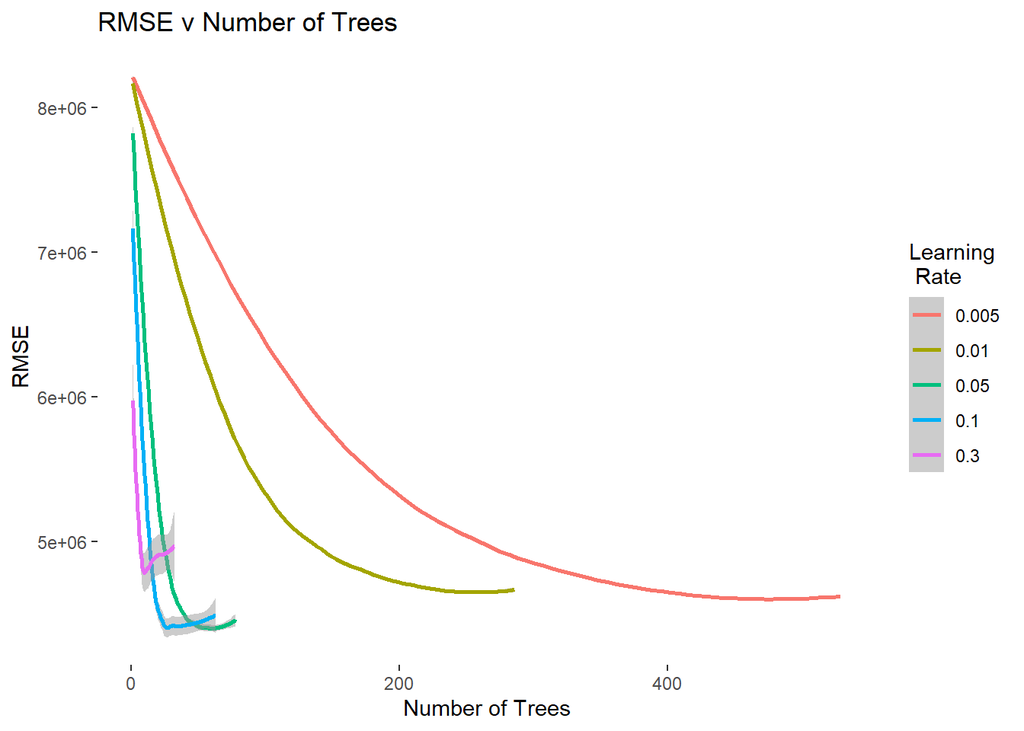

```r
g_7 <- ggplot(plot_data, aes(x = iter, y = test_rmse_mean, color = eta))+
  geom_smooth(alpha = 0.5) +
  theme_bw() + # Set theme
  theme(panel.grid.major = element_blank(), # Remove grid
        panel.grid.minor = element_blank(), # Remove grid
        panel.border = element_blank(), # Remove grid
        panel.background = element_blank()) + # Remove grid
  labs(x = "Number of Trees", title = "RMSE v Number of Trees",
       y = "RMSE", color = "Learning \n Rate")  # Set labels
g_7
```

Here we are looking for the line which reaches the lowest error rate. From this it looks like an eta value of 0.1 gives the best results for this dataset. We decided to use 0.1 because we saw the lowest point of the graph for the line 0.1. We can now fit our final model using our tuned hyper parameters:

```r
# fit final xgb model
set.seed(111111)
bst_final <- xgboost(data = dtrain, # Set training data



                     eta = .1, # Set learning rate
                     max.depth =  3, # Set max depth
                     min_child_weight = 3, # Set minimum number of samples in node to split
                     gamma = .15, # Set minimum loss reduction for split
                     subsample =  0.6, # Set proportion of training data to use in tree
                     colsample_bytree = 1, # Set number of variables to use in each tree

                     nrounds = 100, # Set number of rounds
                     early_stopping_rounds = 20, # Set number of rounds to stop at if there is no improvement

                     verbose = 1, # 1 - Prints out fit
                     nthread = 1, # Set number of parallel threads
                     print_every_n = 20 # Prints out result every 20th iteration

) # Set evaluation metric to use
```

```
## Will train until train_rmse hasn't improved in 20 rounds.
##
```

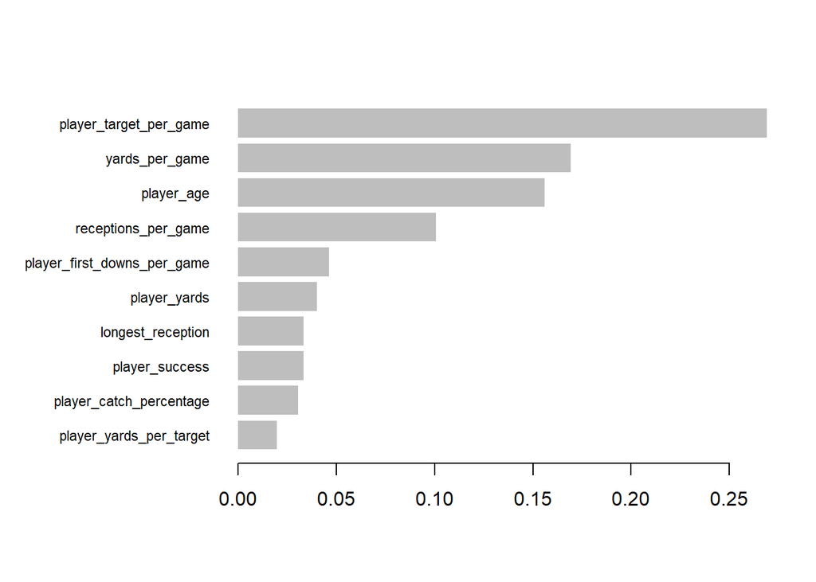

```r
# Extract importance
imp_mat <- xgb.importance(model = bst_final)
# Plot importance (top 10 variables)
xgb.plot.importance(imp_mat, top_n = 10)
```

From this we see that our most important variables for predicting Contract AAV for our model are player_target_per_game, yards_per_game, player_age, and receptions_per_game.

The code below is to help create our waterfall from the XG Explainer. This will allow us to select whichever player we want to predict their Contract AAV based on our waterfall variables. This allows us to create a waterfall visual for the player that shows their predicted Contract AAV.

```r
WR2 <-  WRData %>%
  select(contract_AAV,player_target_per_game, yards_per_game,player_age, receptions_per_game)
WRFIT2 <- lm(contract_AAV~., data= WR2)
summary(WRFIT2)
```

```
##
## Call:
## lm(formula = contract_AAV ~ ., data = WR2)
##
## Residuals:
##       Min        1Q    Median        3Q       Max
## -11734498  -3368224   -438344   2450835  14737447
##
## Coefficients:
##                         Estimate Std. Error t value Pr(>|t|)
## (Intercept)            -19266004    4145828  -4.647 7.82e-06 ***
## player_target_per_game   1218089     858657   1.419   0.1583
## yards_per_game            126701      60386   2.098   0.0377 *
## player_age                706027     160609   4.396 2.19e-05 ***
## receptions_per_game     -1149659    1189366  -0.967   0.3354
## ---
## Signif. codes:  0 '***' 0.001 '**' 0.01 '*' 0.05 '.' 0.1 ' ' 1
##
## Residual standard error: 5150000 on 137 degrees of freedom
## Multiple R-squared:  0.4942, Adjusted R-squared:  0.4794
## F-statistic: 33.46 on 4 and 137 DF,  p-value: < 2.2e-16
```

```r
getTreeBreakdown = function(tree, col_names){

  ####accepts a tree (data table), and column names
  ####outputs a data table, of the impact of each variable + intercept, for each leaf

  tree_breakdown <- vector("list", length(col_names)  + 2)
  names(tree_breakdown) = c(col_names,'intercept','leaf')

  leaves = tree[leaf==T, Node]

  for (leaf in leaves){

    leaf_breakdown = getLeafBreakdown(tree,leaf,col_names)
    leaf_breakdown$leaf = leaf
    tree_breakdown = rbindlist(append(list(tree_breakdown),list(leaf_breakdown)))
  }

  return (tree_breakdown)
}

buildExplainerFromTreeList = function(tree_list,col_names){

  ####accepts a list of trees and column names
  ####outputs a data table, of the impact of each variable + intercept, for each leaf

  tree_list_breakdown <- vector("list", length(col_names)  + 3)
  names(tree_list_breakdown) = c(col_names,'intercept', 'leaf','tree')

  num_trees = length(tree_list)

  cat('\n\nGetting breakdown for each leaf of each tree...\n')
  pb <- txtProgressBar(style=3)

  for (x in 1:num_trees){
    tree = tree_list[[x]]
    tree_breakdown = getTreeBreakdown(tree, col_names)
    tree_breakdown$tree = x - 1
    tree_list_breakdown = rbindlist(append(list(tree_list_breakdown),list(tree_breakdown)))
    setTxtProgressBar(pb, x / num_trees)
  }

  return (tree_list_breakdown)

}


getStatsForTrees = function(trees, nodes.train, type = "binary", base_score = 0.5){
  #Accepts data table of tree (the output of xgb.model.dt.tree)
  #Returns a list of tree, with the stats filled in

  tree_list = copy(trees)
  tree_list[,leaf := Feature == 'Leaf']
  tree_list[,H:=Cover]

  non.leaves = which(tree_list[,leaf]==F)


  # The default cover (H) seems to lose precision so this loop recalculates it for each node of each tree
  cat('\n\nRecalculating the cover for each non-leaf... \n')
  pb <- txtProgressBar(style=3)
  j = 0
  for (i in rev(non.leaves)){
    left = tree_list[i,Yes]
    right = tree_list[i,No]
    tree_list[i,H:=tree_list[ID==left,H] + tree_list[ID==right,H]]
    j=j+1
    setTxtProgressBar(pb, j / length(non.leaves))
  }


  if (type == 'regression'){
    base_weight = base_score
  } else{
    base_weight = log(base_score / (1-base_score))
  }

  tree_list[leaf==T,weight:=base_weight + Quality]

  tree_list[,previous_weight:=base_weight]
  tree_list[1,previous_weight:=0]

  tree_list[leaf==T,G:=-weight*H]

  tree_list = split(tree_list,as.factor(tree_list$Tree))
  num_tree_list = length(tree_list)
  treenums =  as.character(0:(num_tree_list-1))
  t = 0
  cat('\n\nFinding the stats for the xgboost trees...\n')
  pb <- txtProgressBar(style=3)
  for (tree in tree_list){
    t=t+1
    num_nodes = nrow(tree)
    non_leaf_rows = rev(which(tree[,leaf]==F))
    for (r in non_leaf_rows){
        left = tree[r,Yes]
        right = tree[r,No]
        leftG = tree[ID==left,G]
        rightG = tree[ID==right,G]

        tree[r,G:=leftG+rightG]
        w=tree[r,-G/H]

        tree[r,weight:=w]
        tree[ID==left,previous_weight:=w]
        tree[ID==right,previous_weight:=w]
    }

    tree[,uplift_weight:=weight-previous_weight]
    setTxtProgressBar(pb, t / num_tree_list)
  }

  return (tree_list)
}


getLeafBreakdown = function(tree,leaf,col_names){

  ####accepts a tree, the leaf id to breakdown and column names
  ####outputs a list of the impact of each variable + intercept

  impacts = as.list(rep(0,length(col_names)))
  names(impacts) = col_names

  path = findPath(tree,leaf)
  reduced_tree = tree[Node %in% path,.(Feature,uplift_weight)]

  impacts$intercept=reduced_tree[1,uplift_weight]
  reduced_tree[,uplift_weight:=shift(uplift_weight,type='lead')]

  tmp = reduced_tree[,.(sum=sum(uplift_weight)),by=Feature]
  tmp = tmp[-nrow(tmp)]
  impacts[tmp[,Feature]]=tmp[,sum]

  return (impacts)
}

findPath = function(tree, currentnode, path = c()){

  #accepts a tree data table, and the node to reach
  #path is used in the recursive function - do not set this

  while(currentnode>0){
    path = c(path,currentnode)
    currentlabel = tree[Node==currentnode,ID]
    currentnode = c(tree[Yes==currentlabel,Node],tree[No==currentlabel,Node])
  }
  return (sort(c(path,0)))

}


findLeaves = function(tree, currentnode){

  if (tree[currentnode,'Feature']=='Leaf'){
    leaves = currentnode
  }else{
    leftnode = tree[currentnode,Yes]
    rightnode = tree[currentnode,No]
    leaves = c(findLeaves(tree,'leftnode',with=FALSE),findLeaves(tree,'rightnode',with=FALSE))
  }

  return (sort(leaves))


}



buildExplainer = function(xgb.model,
                          trainingData,

                          type = "binary", base_score = 0.5, trees_idx = NULL){

  col_names = colnames(trainingData)
  cat('\nCreating the trees of the xgboost model...')
  trees = xgb.model.dt.tree(col_names, model = xgb.model, trees = trees_idx)
  cat('\nGetting the leaf nodes for the training set observations...')
  nodes.train = predict(xgb.model,trainingData,predleaf =TRUE)

  cat('\nBuilding the Explainer...')
  cat('\nSTEP 1 of 2')
  tree_list = getStatsForTrees(trees, nodes.train, type = type, base_score = base_score)
  cat('\n\nSTEP 2 of 2')
  explainer = buildExplainerFromTreeList(tree_list,col_names)

  cat('\n\nDONE!\n\n')

  return (explainer)
}
```

```r
explainer = buildExplainer(bst_final, dtrain, type="regression", base_score = 0.5, trees_idx = NULL) # Create explainer
```

```
##
## Creating the trees of the xgboost model...
## Getting the leaf nodes for the training set observations...
## Building the Explainer...
## STEP 1 of 2
##
## Recalculating the cover for each non-leaf...
##
##
## Finding the stats for the xgboost trees...
##
##
## STEP 2 of 2
##
## Getting breakdown for each leaf of each tree...
##
##
## DONE!
```

```r
pred.breakdown = explainPredictions(bst_final, explainer, dtest) # Breakdown predictions
```

```
##
##
## Extracting the breakdown of each prediction...
##
##
## DONE!
```

```r
showWaterfall(bst_final, explainer, dtest, as.matrix(WR_test[, c(3, 5:21)]) ,1, type = "regression", threshold = 0.07)
```

```
##
##
## Extracting the breakdown of each prediction...
##
##
## DONE!
##
## Actual:  1.1e+07
## Prediction:  12160798
## Weight:  12160798
## Breakdown
##                   intercept                  player_age
##                  5547738.93                  3201592.16
##         receptions_per_game     player_catch_percentage
##                  1602678.89                   801948.57
##                player_yards                  player_rec
##                   712243.89                   624847.23
## player_first_downs_per_game                games_played
##                   615329.23                  -406882.50
##           longest_reception     player_yards_per_target
##                  -339483.86                  -249100.18
##      player_target_per_game                   player_td
##                   239050.05                   202958.42
##               games_started              yards_per_game
##                  -197947.66                  -155219.12
##              player_success          player_first_downs
##                   117585.65                   -88124.08
##          player_td_per_game                  player_ypr
##                   -79192.25                    39456.39
##              player_targets
##                   -28681.47
```

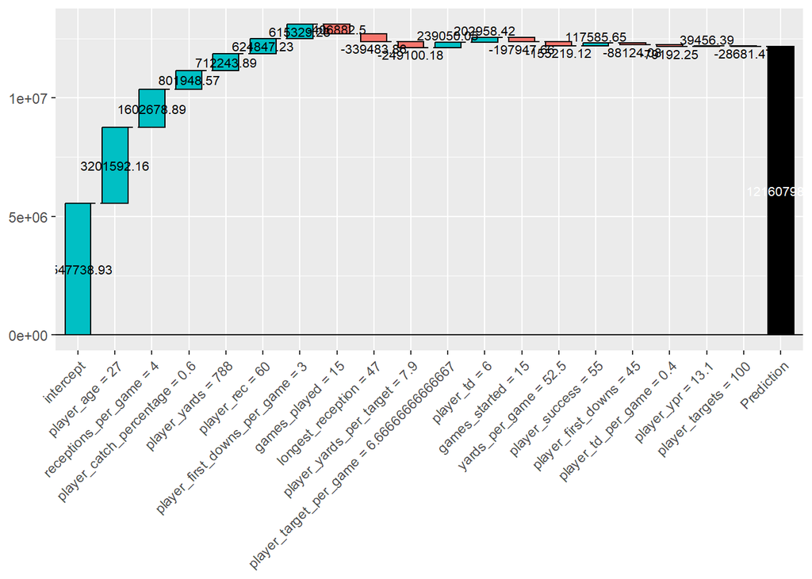

Allen Lazard contract AAV: actual: $11,000,000 prediction: 12,160,798

We used Allen Lazard because he just got paid this offseason based on his 2022 statistics.

```r
showWaterfall(bst_final, explainer, dtest, as.matrix(WR_train[, c(3, 5:21)]) ,14, type = "regression", threshold = 0.07)
```

```
##
##
## Extracting the breakdown of each prediction...
##
##
## DONE!
##
## Actual:  7704910
## Prediction:  16171029
## Weight:  16171029
## Breakdown
##                   intercept              yards_per_game
##                  5547738.93                  7419403.83
##                  player_age         receptions_per_game
##                 -5540309.14                  3153377.79
##      player_target_per_game          player_td_per_game
##                  3143280.79                   863978.08
##                   player_td           longest_reception
##                   698609.29                   613570.12
##     player_catch_percentage                player_yards
##                  -544268.61                   526998.91
##              player_success              player_targets
##                  -442899.36                   437868.83
## player_first_downs_per_game          player_first_downs
##                   416772.08                   246297.60
##               games_started                  player_ypr
##                  -144981.00                  -122868.06
##                  player_rec                games_played
##                   -55351.47                   -25117.70
##     player_yards_per_target
##                   -21072.38
```

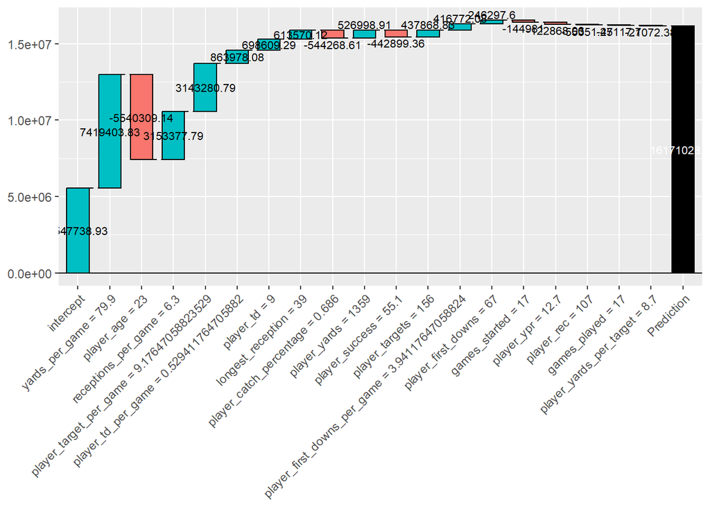

CeeDee Lamb contract AAV: Prediction: $16,171,029

Player above is CeeDee Lamb, on rookie deal, predictor evaluates him as almost double of what he should recieve.

```r
showWaterfall(bst_final, explainer, dtest, as.matrix(WR_train[, c(3, 5:21)]) ,14, type = "regression", threshold = 0.07)
```

```
##
##
## Extracting the breakdown of each prediction...
##
##
## DONE!
##
## Actual:  7704910
## Prediction:  16171029
## Weight:  16171029
## Breakdown
##                   intercept              yards_per_game
##                  5547738.93                  7419403.83
##                  player_age         receptions_per_game
##                 -5540309.14                  3153377.79
##      player_target_per_game          player_td_per_game
##                  3143280.79                   863978.08
##                   player_td           longest_reception
##                   698609.29                   613570.12
##     player_catch_percentage                player_yards
##                  -544268.61                   526998.91
##              player_success              player_targets
##                  -442899.36                   437868.83
## player_first_downs_per_game          player_first_downs
##                   416772.08                   246297.60
##               games_started                  player_ypr
##                  -144981.00                  -122868.06
##                  player_rec                games_played
##                   -55351.47                   -25117.70
##     player_yards_per_target
##                   -21072.38
```

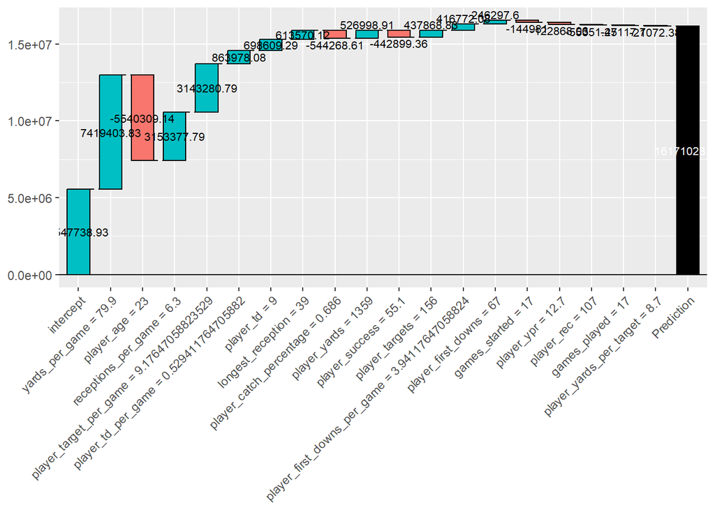

# Random Forest

```r
rf_mod_wr <- randomForest(contract_AAV ~.,
                          data = WR_train[,c(3, 5:21,24)],
                          ntree = 200,
                          nodesize = 1)
rf_pred_wr <- predict(rf_mod_wr, WR_test)

rf_mod_wr
```

```
##
## Call:
##  randomForest(formula = contract_AAV ~ ., data = WR_train[, c(3,      5:21, 24)], ntree = 200, nodesize = 1)
##                Type of random forest: regression
##                      Number of trees: 200
## No. of variables tried at each split: 6
##
##           Mean of squared residuals: 2.145703e+13
##                     % Var explained: 57.11
```

```r
tree_1 <- getTree(rf_mod_wr, 3, labelVar=TRUE) # Extract single tree,
head(tree_1)
```

```
##   left daughter right daughter              split var split point status
## 1             2              3 player_target_per_game      7.0181     -3
## 2             4              5          games_started      9.5000     -3
## 3             6              7         yards_per_game     72.8000     -3
## 4             8              9    receptions_per_game      3.8000     -3
## 5            10             11             player_age     27.5000     -3
## 6            12             13    receptions_per_game      5.4500     -3
##   prediction
## 1    4736761
## 2    3070000
## 3   14149062
## 4    1984409
## 5    5346238
## 6   12250647
```

```r
oob_error <- rf_mod_wr$mse
oob_error
```

```
##   [1] 3.997491e+13 3.295875e+13 3.011132e+13 2.916914e+13 3.249394e+13
##   [6] 2.732451e+13 2.286582e+13 2.622528e+13 2.568971e+13 2.762278e+13
##  [11] 2.763483e+13 2.808727e+13 2.678652e+13 2.558720e+13 2.595321e+13
##  [16] 2.538187e+13 2.555664e+13 2.370849e+13 2.314521e+13 2.258619e+13
##  [21] 2.277587e+13 2.235064e+13 2.283305e+13 2.320548e+13 2.253151e+13
##  [26] 2.212406e+13 2.277813e+13 2.316947e+13 2.339162e+13 2.261985e+13
##  [31] 2.260343e+13 2.236911e+13 2.188356e+13 2.193663e+13 2.246997e+13
##  [36] 2.185757e+13 2.178084e+13 2.154079e+13 2.187794e+13 2.209904e+13
##  [41] 2.203701e+13 2.196603e+13 2.207863e+13 2.197005e+13 2.211774e+13
##  [46] 2.214937e+13 2.213455e+13 2.237102e+13 2.265912e+13 2.245496e+13
##  [51] 2.244165e+13 2.204400e+13 2.232108e+13 2.251376e+13 2.238694e+13
##  [56] 2.243207e+13 2.254443e+13 2.221028e+13 2.210715e+13 2.189866e+13
##  [61] 2.197978e+13 2.214016e+13 2.189943e+13 2.218425e+13 2.205502e+13
##  [66] 2.201556e+13 2.185693e+13 2.201980e+13 2.201099e+13 2.179159e+13
##  [71] 2.187001e+13 2.172383e+13 2.169204e+13 2.163358e+13 2.152966e+13
```

[output cut: 25 more lines]

```r
length(oob_error)
```

```
## [1] 200
```

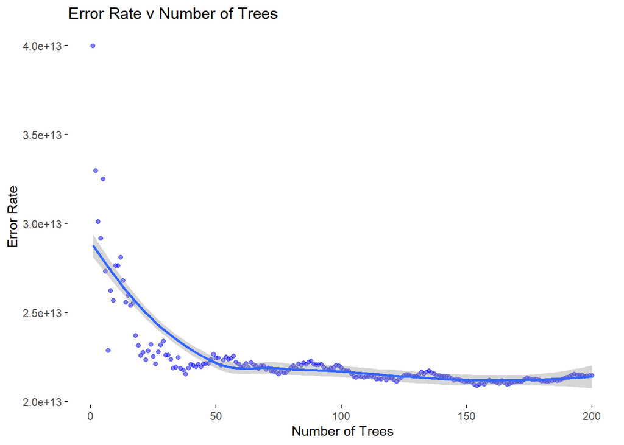

```r
plot_dat <- cbind.data.frame(rep(1:length(oob_error)), oob_error) # Create plot data
names(plot_dat) <- c("trees", "oob_error")


# Plot oob error
g_1 <- ggplot(plot_dat, aes(x = trees, y = oob_error)) + # Set x as trees and y as error
  geom_point(alpha = 0.5, color = "blue") + # Select geom point
  geom_smooth() + # Add smoothing line
  theme_bw() + # Set theme
  theme(panel.grid.major = element_blank(), # Remove grid
        panel.grid.minor = element_blank(), # Remove grid
        panel.border = element_blank(), # Remove grid
        panel.background = element_blank()) + # Remove grid
  labs(x = "Number of Trees", title = "Error Rate v Number of Trees",
       y = "Error Rate")  # Set labels
g_1 # Print plot
```

```r
rf_mod_wr2 <- randomForest(contract_AAV ~.,
                          data = WR_train[,c(3, 5:21,24)],
                          ntree = 1000,
                          nodesize = 1)
rf_pred_wr2 <- predict(rf_mod_wr2, WR_test)
rf_mod_wr2
```

```
##
## Call:
##  randomForest(formula = contract_AAV ~ ., data = WR_train[, c(3,      5:21, 24)], ntree = 1000, nodesize = 1)
##                Type of random forest: regression
##                      Number of trees: 1000
## No. of variables tried at each split: 6
##
##           Mean of squared residuals: 2.145509e+13
##                     % Var explained: 57.11
```

```r
oob_error <- rf_mod_wr2$mse # Extract oob error
length(oob_error)
```

```
## [1] 1000
```

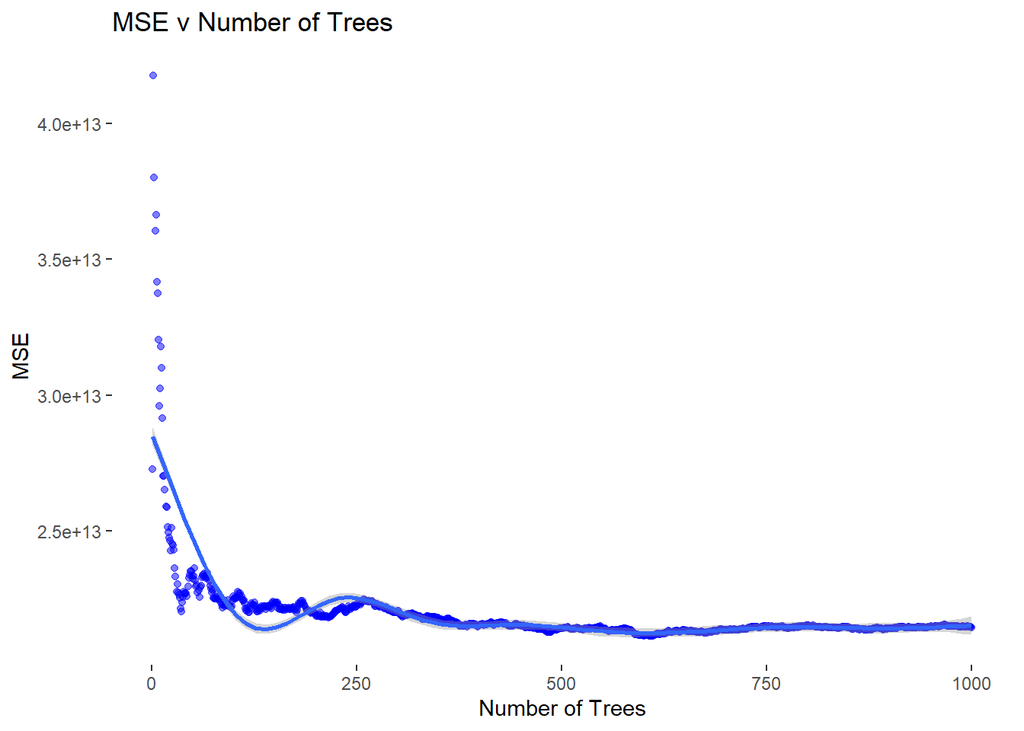

```r
plot_dat <- cbind.data.frame(rep(1:length(oob_error)), oob_error) # Create plot data
names(plot_dat) <- c("trees", "oob_error") # Name plot data


# Plot oob error
g_2 <- ggplot(plot_dat, aes(x = trees, y = oob_error)) + # Set x as trees and y as error
  geom_point(alpha = 0.5, color = "blue") + # Select geom point
  geom_smooth() + # Add smoothing line
  theme_bw() + # Set theme
  theme(panel.grid.major = element_blank(), # Remove grid
        panel.grid.minor = element_blank(), # Remove grid
        panel.border = element_blank(), # Remove grid
        panel.background = element_blank()) + # Remove grid
  labs(x = "Number of Trees", title = "MSE v Number of Trees",
       y = "MSE")  # Set labels
g_2 # Create plot
```

Here we see that initially the error rate falls significantly and then levels off after about a little past 250 trees, though there is a slight continuous improvement as the number of trees increases. The plot also shows that the model did not improve significantly from 375 trees to 1000 trees.

# Parameter Tuning

```r
# Careful this can take a long time to run
trees <- c(10, 25, 50, 100, 200, 500, 1000) # Create vector of possible tree sizes
nodesize <- c(1, 10, 25, 50, 100, 200, 500, 1000) # Create vector of possible node sizes

params <- expand.grid(trees, nodesize) # Expand grid to get data frame of parameter combinations
names(params) <- c("trees", "nodesize") # Name parameter data frame
res_vec <- rep(NA, nrow(params)) # Create vector to store accuracy results

for(i in 1:nrow(params)){ # For each set of parameters
  set.seed(987654) # Set seed for reproducability
  mod <- randomForest(contract_AAV ~.,
                          data = WR_train[,c(3, 5:21,24)], # Set data
                      mtry = 4, # Set number of variables
                      importance = FALSE,  #
                      ntree = params$trees[i], # Set number of trees
                      nodesize = params$nodesize[i]) # Set node size
  res_vec[i] <-  mod$mse[length(mod$mse)] #Professor Martin the issue with length is here. I messed with this equation a little
}
```

```r
summary(res_vec)
```

```
##      Min.   1st Qu.    Median      Mean   3rd Qu.      Max.
## 2.216e+13 2.619e+13 3.033e+13 2.912e+13 3.172e+13 4.030e+13
```

```r
res_db <- cbind.data.frame(params, res_vec) # Join parameters and accuracy results
names(res_db)[3] <- "mse" # Name accuracy results column
res_db # Print accuracy results column
```

```
##    trees nodesize          mse
## 1     10        1 3.071693e+13
## 2     25        1 2.709851e+13
## 3     50        1 2.651163e+13
## 4    100        1 2.359011e+13
## 5    200        1 2.235026e+13
## 6    500        1 2.291206e+13
## 7   1000        1 2.216215e+13
## 8     10       10 4.029722e+13
## 9     25       10 2.945728e+13
## 10    50       10 2.678040e+13
## 11   100       10 2.410646e+13
## 12   200       10 2.304921e+13
## 13   500       10 2.243426e+13
## 14  1000       10 2.223596e+13
```

[output cut: 42 more lines]

In the code above, we analyze the combinations of parameters with our MSE. Next, we decide to visualize this.

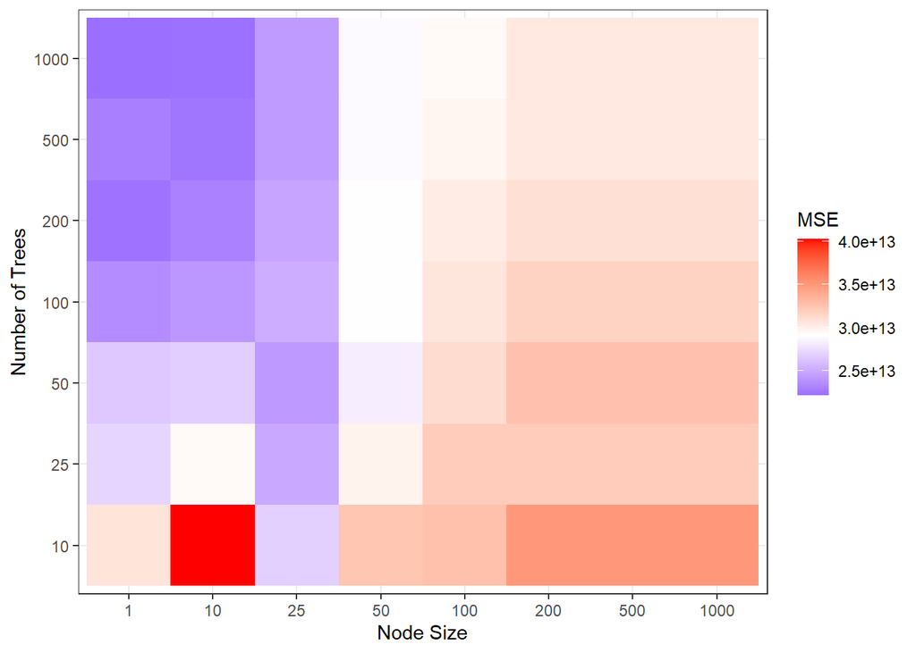

```r
res_db$trees <- as.factor(res_db$trees) # Convert tree number to factor for plotting
res_db$nodesize <- as.factor(res_db$nodesize) # Convert node size to factor for plotting
g_2 <- ggplot(res_db, aes(y = trees, x = nodesize, fill = mse)) + # set aesthetics
  geom_tile() + # Use geom_tile for heatmap
  theme_bw() + # Set theme
  scale_fill_gradient2(low = "blue", # Choose low color
    mid = "white", # Choose mid color
    high = "red", # Choose high color
    midpoint =mean(res_db$mse), # Choose mid point
    space = "Lab",
    na.value ="grey", # Choose NA value
    guide = "colourbar", # Set color bar
    aesthetics = "fill") + # Select aesthetics to apply
  labs(x = "Node Size", y = "Number of Trees", fill = "MSE") # Set labels
g_2 # Generate plot
```

```r
res_db[which.min(res_db$mse),] # View best set of results
```

```
##   trees nodesize          mse
## 7  1000        1 2.216215e+13
```

From the code above, we found the correct number of trees and nodesize for our lowest MSE. 1000 trees and a node size of 1 is the lowest MSE.

```r
set.seed(123456)
rf_mod_wr3 <- randomForest(contract_AAV ~., # Set tree formula
               data = WR_train[,c(3, 5:21,24)], # Set dataset

                ntree = 1000, # Set number of trees
                nodesize = 1) # Set node size


rf_pred_wr3 <- predict(rf_mod_wr3, WR_test)
rf_mod_wr3
```

```
##
## Call:
##  randomForest(formula = contract_AAV ~ ., data = WR_train[, c(3,      5:21, 24)], ntree = 1000, nodesize = 1)
##                Type of random forest: regression
##                      Number of trees: 1000
## No. of variables tried at each split: 6
##
##           Mean of squared residuals: 2.171692e+13
##                     % Var explained: 56.59
```

Here we see that our mean of squared residuals and % of Variability Explained stay very close to our previous rf_mod_wr_2.

```r
rf_mod_wr4 <- randomForest(contract_AAV ~., # Set tree formula
                data = WR_train[,c(3, 5:21,24)], # Set dataset

                ntree = 1000, # Set number of trees
                nodesize = 1,  # Set node size
                importance = TRUE, # Set to true to generate importance matrix
                proximity = TRUE) # Set to true to generate proximity matrix

rf_pred_wr4 <- predict(rf_mod_wr4, WR_test)
rf_mod_wr4
```

```
##
## Call:
##  randomForest(formula = contract_AAV ~ ., data = WR_train[, c(3,      5:21, 24)], ntree = 1000, nodesize = 1, importance = TRUE,      proximity = TRUE)
##                Type of random forest: regression
##                      Number of trees: 1000
## No. of variables tried at each split: 6
##
##           Mean of squared residuals: 2.061176e+13
##                     % Var explained: 58.8
```

```r
# Extract Importance
importance_matrix <- randomForest::importance(rf_mod_wr4)
# Print importance matrix
importance_matrix
```

```
##                               %IncMSE IncNodePurity
## player_age                  24.736459  5.576966e+14
## games_played                 1.344164  6.619093e+13
## games_started                4.440351  8.722149e+13
## player_targets               9.163571  3.146388e+14
## player_rec                   8.500574  2.577534e+14
## player_catch_percentage      1.736904  1.317557e+14
## player_yards                 8.627342  2.406427e+14
## player_ypr                   1.890395  1.057903e+14
## player_td                    2.855006  8.312130e+13
## player_first_downs          10.388791  2.630626e+14
## player_success               2.627381  9.953944e+13
## longest_reception            1.485084  1.345161e+14
## player_yards_per_target      2.488448  1.065718e+14
## receptions_per_game         13.747131  5.120639e+14
## yards_per_game              13.753432  6.784490e+14
## player_target_per_game      21.507881  1.147240e+15
## player_td_per_game           4.175350  1.706208e+14
## player_first_downs_per_game 19.014635  5.991923e+14
```

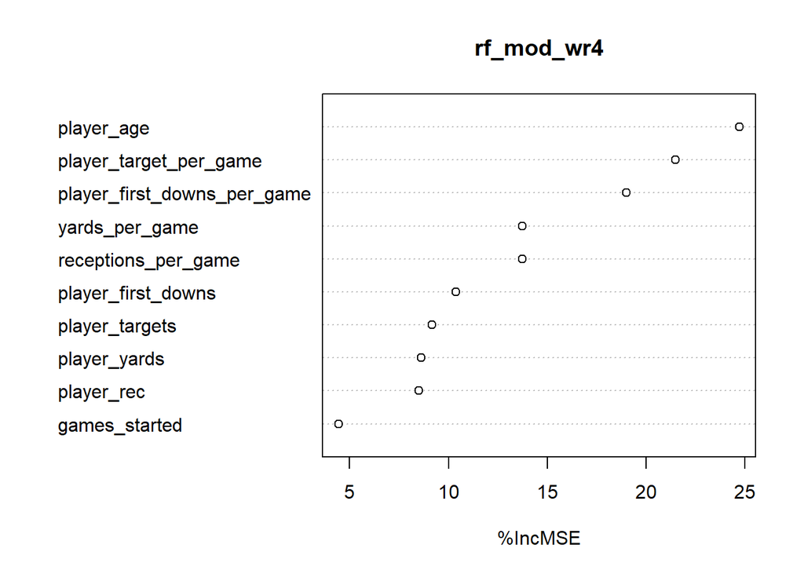

```r
varImpPlot(rf_mod_wr4, type =1, n.var = 10) # Plot importance
```

This shows that the most important factors for determining MSE are age, player_target_per_game, player_first_downs_per_game, and receptions_per_game, and yards_per_game.

The only difference between our xgboost and random forest important factors is a different order of importance of these 5 factors depending on the model.

# Comparing the two models

```r
xgb_preds <- predict(bst_final, dtest)


library(Metrics)
rmse(WR_test$contract_AAV, xgb_preds)
```

```
## [1] 4603243
```

```r
rf_preds <- predict(rf_mod_wr4, WR_test[,c(3, 5:21,24)])


temp <- cbind.data.frame(WR_test$contract_AAV, rf_preds)
temp <- na.omit(temp)
rmse(temp$`WR_test$contract_AAV`, temp$rf_preds)
```

```
## [1] 4930344
```

When comparing the two models (XGBoost and Random Forest), we found that XGBoost model was better because it had a lower RMSE. The XGboost model had a lower RMSE by about 300,000.